# General(ized) Linear Models: Interactions

Last updated: 2017-03-04

## Factorial designs and interactions

**Factorial designs** all combinations of treatments are included:

|  | \(X_1\) Group A | \(X_1\) Group B |
| --- | --- | --- |
| \(X_2\) Group A | \(X_1\) A, \(X_2\) A | \(X_1\) B, \(X_1\) A |
| \(X_2\) Group B | \(X_1\) A, \(X_2\) B | \(X_1\) B, \(X_1\) B |

- Allow you to explore *interactions* (multiplicative effects)

If you have multiple categorical variables, you should *always* do factorial designs (unless you know why you aren't).

## Interaction model

Add a new predictor (\(\beta_3\)) that is the product of \(X_1\) and \(X_2\):

\[Y = \beta_0 + \beta_1 X_1 + \beta_2 X_2 + \beta_3 (X_1 X_2) + \epsilon\]

The value of \(X_1\) varies with change in the value of \(X_2\) (and vice versa - these are not really separable).

## Factorial data

Weight gain in rats fed two diets with high and low protein from two different sources.

```r
data("weightgain", package = "HSAUR3")
WG <- weightgain
str(WG)
```

```
## 'data.frame':    40 obs. of  3 variables:
##  $ source    : Factor w/ 2 levels "Beef","Cereal": 1 1 1 1 1 1 1 1 1 1 ...
##  $ type      : Factor w/ 2 levels "High","Low": 2 2 2 2 2 2 2 2 2 2 ...
##  $ weightgain: int  90 76 90 64 86 51 72 90 95 78 ...
```

## Factorial data

Balanced data: Equal *n* in each group

```r
WG %>% group_by(source, type) %>% tally()
```

```
## Source: local data frame [4 x 3]
## Groups: source [?]
##
##   source   type     n
##   <fctr> <fctr> <int>
## 1   Beef   High    10
## 2   Beef    Low    10
## 3 Cereal   High    10
## 4 Cereal    Low    10
```

Balanced data is the best to work with.

## Visualizing factorial data

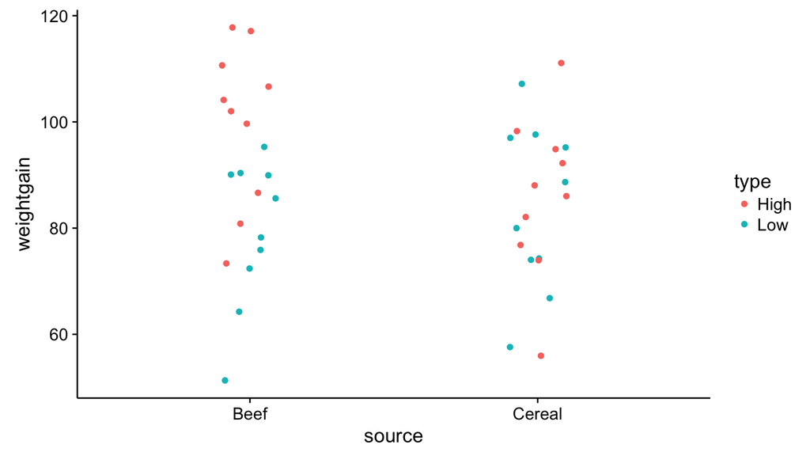

## Interaction plot

```r
ggplot(WG, aes(x = source,
               y = weightgain,
               color = type,
               group = type)) +
  geom_point(position = position_jitter(width = 0.1)) +
  stat_summary(fun.y = mean, geom = "point", pch = 12, size = 5) +
  stat_summary(fun.y = mean, geom = "line")
```

## Interaction plot

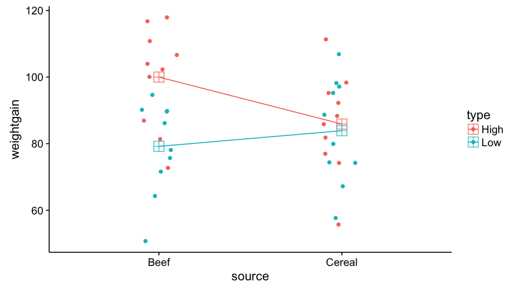

## Interaction plot

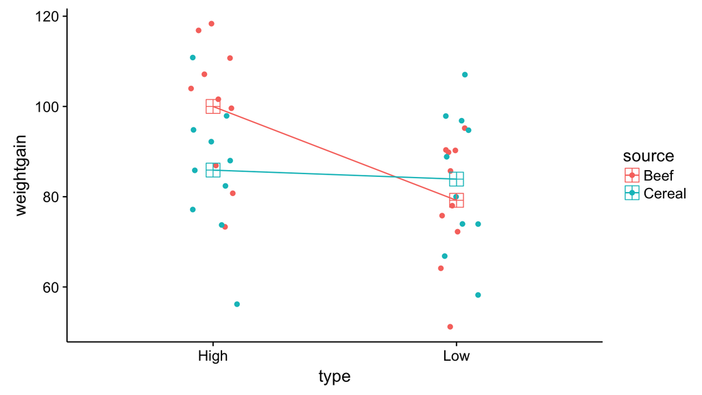

## Group means

```r
WG %>% group_by(source, type) %>%
  summarize(mean = mean(weightgain))
```

```
## Source: local data frame [4 x 3]
## Groups: source [?]
##
##   source   type  mean
##   <fctr> <fctr> <dbl>
## 1   Beef   High 100.0
## 2   Beef    Low  79.2
## 3 Cereal   High  85.9
## 4 Cereal    Low  83.9
```

## Two-way factorial ANOVA

```r
fm <- lm(weightgain ~ source * type, data = WG)
```

`source * type` expands to:

```r
fm <- lm(weightgain ~ source + type + source:type, data = WG)
```

`source:type` is the interaction term

## Two-way factorial ANOVA

```r
summary(fm)
```

```
##
## Call:
## lm(formula = weightgain ~ source * type, data = WG)
##
## Residuals:
##    Min     1Q Median     3Q    Max
## -29.90  -9.90   2.05  10.85  25.10
##
## Coefficients:
##                      Estimate Std. Error t value Pr(>|t|)
## (Intercept)           100.000      4.729  21.148  < 2e-16
## sourceCereal          -14.100      6.687  -2.109  0.04201
## typeLow               -20.800      6.687  -3.110  0.00364
## sourceCereal:typeLow   18.800      9.457   1.988  0.05447
##
## Residual standard error: 14.95 on 36 degrees of freedom
## Multiple R-squared:   0.23,  Adjusted R-squared:  0.1658
## F-statistic: 3.584 on 3 and 36 DF,  p-value: 0.02297
```

## ANOVA table

```r
fm2 <- lm(weightgain ~ type * source, data = WG)
anova(fm2)
```

```
## Analysis of Variance Table
##
## Response: weightgain
##             Df Sum Sq Mean Sq F value  Pr(>F)
## type         1 1299.6 1299.60  5.8123 0.02114
## source       1  220.9  220.90  0.9879 0.32688
## type:source  1  883.6  883.60  3.9518 0.05447
## Residuals   36 8049.4  223.59
```

## Interpretations

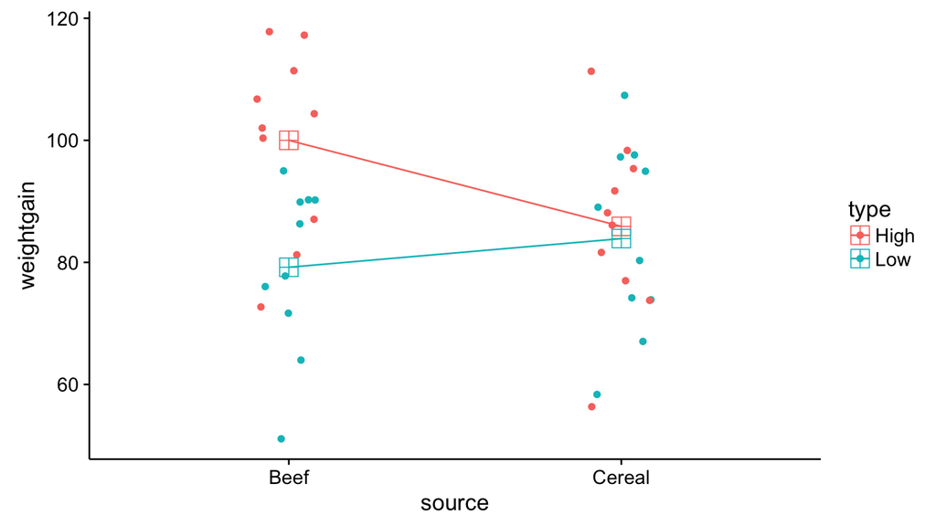

## Power to detect interactions is low (Wahlsten 1990)

For a 2 X 2 design

- Power to detect a main effect is 87%
- Power to detect the interaction is 16%

ANOVA will suggest additivity of effects when in fact they are multiplicative

## Under the hood

Numeric representations of `source` and `type`:

```r
WG$source_num <- ifelse(WG$source == "Beef", 0, 1)
WG$type_num <- ifelse(WG$type == "High", 0, 1)
```

Numeric representation of the interaction (multiple the other two numeric representations):

```r
WG$interact <- WG$source_num * WG$type_num
```

1's only for the "Cereal" & "Low" groups. 0's for all others.

## 4 parameters define 4 groups

1. \(\beta_0\) = `(Intercept)` = "Beef" & "High" group mean
2. \(\beta_1\) = `source_num` = "Cereal" & "High" addition
3. \(\beta_2\) = `type_num` = "Beef" & "Low" addition
4. \(\beta_3\) = `interact` = #2 + #3 + "Cereal" & "Low" addition

## Under the hood

```r
summary(lm(weightgain ~ source_num + type_num + interact, data = WG))
```

```
##
## Call:
## lm(formula = weightgain ~ source_num + type_num + interact, data = WG)
##
## Residuals:
##    Min     1Q Median     3Q    Max
## -29.90  -9.90   2.05  10.85  25.10
##
## Coefficients:
##             Estimate Std. Error t value Pr(>|t|)
## (Intercept)  100.000      4.729  21.148  < 2e-16
## source_num   -14.100      6.687  -2.109  0.04201
## type_num     -20.800      6.687  -3.110  0.00364
## interact      18.800      9.457   1.988  0.05447
##
## Residual standard error: 14.95 on 36 degrees of freedom
## Multiple R-squared:   0.23,  Adjusted R-squared:  0.1658
## F-statistic: 3.584 on 3 and 36 DF,  p-value: 0.02297
```

## Model matrix

R does the factor \(\rightarrow\) numeric conversion behind the scenes:

```r
model.matrix(weightgain ~ source * type, data = WG)
```

```
##    (Intercept) sourceCereal typeLow sourceCereal:typeLow
## 1            1            0       1                    0
## 2            1            0       1                    0
## 3            1            0       1                    0
## 4            1            0       1                    0
## 5            1            0       1                    0
## 6            1            0       1                    0
## 7            1            0       1                    0
## 8            1            0       1                    0
## 9            1            0       1                    0
## 10           1            0       1                    0
## 11           1            0       0                    0
## 12           1            0       0                    0
## 13           1            0       0                    0
## 14           1            0       0                    0
```

[output cut: 34 more lines]

## Into the abyss…

ANOVA tables, sums of squares, and hypothesis tests.

- As soon as there are interactions with an unbalanced design, variables can share variance.

Questions get complicated:

1. What is the effect of variable 1 on y, ignoring variable 2?
2. What is the effect of variable 2 on y, ignoring variable 1?
3. What is the effect of variable 1 on y, controlling for variable 2?
4. What is the effect of variable 2 on y, controlling for variable 1?

## Partitioning variance

Different ways to partition variance has a cascading effect:

- Determines sums of squares, which
- Determines mean squares, which
- Determines *P* values

Thus you should be aware of how your ANOVA table is calculated.

## Types of sums of squares

**Type I**: "sequential", "unweighted", ordering of factors in the model matters, the R default, probably not what you want *if you have unbalanced sample sizes*

**Type II**: main effects allowed to overlap with their interaction terms, useful if interaction is weak

**Type III**: "weighted", each reported effect controls for all the others (including interactions)

## Types of sums of squares

Each type tests subtly different hypotheses.

- I almost never test your intentions (though it is the mathematical statistician's preference)
- I == III if the groups are balanced (ideal situation - you don't have to choose)
- III matches the output of `summary(lm())` (so that's nice)

## Unbalanced groups

Randomly drop 5 rows:

```r
set.seed(15)
WG_ub <- WG %>% slice(sample(1:nrow(.), nrow(.) - 5))
WG_ub %>% group_by(source, type) %>% tally()
```

```
## Source: local data frame [4 x 3]
## Groups: source [?]
##
##   source   type     n
##   <fctr> <fctr> <int>
## 1   Beef   High     8
## 2   Beef    Low    10
## 3 Cereal   High     8
## 4 Cereal    Low     9
```

## ANOVA Model 1

```r
fm1 <- lm(weightgain ~ source * type, data = WG_ub)
anova(fm1)
```

```
## Analysis of Variance Table
##
## Response: weightgain
##             Df Sum Sq Mean Sq F value  Pr(>F)
## source       1   69.2   69.22  0.3571 0.55448
## type         1 1125.6 1125.61  5.8065 0.02209
## source:type  1  703.3  703.30  3.6280 0.06613
## Residuals   31 6009.5  193.85
```

## ANOVA Model 2

```r
fm2 <- lm(weightgain ~ type * source, data = WG_ub)
anova(fm2)
```

```
## Analysis of Variance Table
##
## Response: weightgain
##             Df Sum Sq Mean Sq F value  Pr(>F)
## type         1 1110.2 1110.24  5.7272 0.02295
## source       1   84.6   84.58  0.4363 0.51378
## type:source  1  703.3  703.30  3.6280 0.06613
## Residuals   31 6009.5  193.85
```

## Type III sums of squares

```r
library(car)
Anova(fm1, type = "III")
```

```
## Anova Table (Type III tests)
##
## Response: weightgain
##             Sum Sq Df  F value  Pr(>F)
## (Intercept)  79003  1 407.5392 < 2e-16
## source         663  1   3.4204 0.07395
## type          1809  1   9.3319 0.00460
## source:type    703  1   3.6280 0.06613
## Residuals     6009 31
```

## Type III sums of squares

```r
library(car)
Anova(fm2, type = "III")
```

```
## Anova Table (Type III tests)
##
## Response: weightgain
##             Sum Sq Df  F value  Pr(>F)
## (Intercept)  79003  1 407.5392 < 2e-16
## type          1809  1   9.3319 0.00460
## source         663  1   3.4204 0.07395
## type:source    703  1   3.6280 0.06613
## Residuals     6009 31
```

## Key points

1. Check your sample sizes within groups
2. Pay attention when you have interaction terms
3. Think about your sums of squares
4. Type II or Type III is likely what you want

## Higher order interaction terms

It is difficult enough to interpret an interaction in a 2 X 2 ANOVA model.

- Higher order terms multiply and become impossible to comprehend

\[Y = \beta_0 + \beta_1 Sex \times \beta_2 Wheel \times \beta_3 Linetype\]

- What does a significant Sex X Wheel X Linetype interaction mean?

Split your data and do two analyses unless you really must.

## I really want to know more about these Type III sums of squares

- https://www.stats.ox.ac.uk/pub/MASS3/Exegeses.pdf
- http://stats.stackexchange.com/q/60362/597
- http://www.matthewckeller.com/TypeIorTypeIIISS.pdf

## These disagreements are all specific to sums of squares and variance component estimation.

Alternatives:

- Model Comparisons & Likelihood
- Bayesian Analyses

## Quiz 08-2

Watch Lecture 08-3

## References

Wahlsten, D. 1990. Insensitivity of the Analysis of Variance to Heredity-Environment Interaction. *The Behavioral and brain sciences* 13:109–120.